# MY472 MT 2020 - Assignment 5

In this assignment, you will analyse political tweets from the time of the 2017 UK General Election campaign. The tweet data can be downloaded from this dropbox [link](https://www.dropbox.com/sh/ktl1a3672yl6te0/AAA2At9pSt9hZ-KsaT0Mwbp2a?dl=0). The files contain tweets from candidates and parties, and replies to these accounts.

Note that the files in the dropbox link are compressed. Information on candidates, parties and associated Twitter accounts can be found in “candidate_information.csv” in the repo. This e.g. allows you to find out which tweets and users belong to politicians/parties and which ones are replies from other users, but the file also contains other information.

**Exercise 1.**

There are 113 tar.gz files in the dropbox folder containing JSON files with both tweets and user information. In this exercise, you are asked to process all files into a relational database (just like in the lecture and class use `DBI` with `SQLite` to create and query this database). There can be several strategies to read the files into R, one is to use the `readtext` function from the `readtext` package which can read compressed files directly (hint: you should also check out the `source` argument in this function which has an option tailored directly to Twitter data).

The goal is to separate the fields in the JSON documents containing tweet and user information into two tables of a relational database. You can name these tables `tweets` and `users`. Before you write the tables into your database, you can process the tweet data with `dplyr` or other packages. Make sure that there are no duplicates among the users and tweets in the final database (i.e. the tweet id is **unique** in the `tweets` table, and the user id is **unique** in `users` table). Also make sure that these two tables can be combined afterwards using a column common to the tables. Please also add one indicator column (i.e. either TRUE/FALSE or 1/0) to each of your tables, in detail:

- A column “screen_name_in” in the `users` table indicating whether an account is among the politician/party accounts
- A column “in_reply_to_screen_name_in” in the `tweets` table indicating whether a tweet was a reply to a politician/party account

(Hint: You can use the file “candidate_information.csv” to determine which users and tweets are from the politicians/parties and which ones are not)

Create a relational database containing the two tables.

**Important note: Please store the files with tweets and your database outside this repo. We will grade the knitted HTML document and do not require these large files.**

```r
# Loading all relevant packages for this assignment
suppressMessages(library(RSQLite))
suppressMessages(library(DBI))
suppressMessages(library(bigrquery))
suppressMessages(library(tidyverse))
suppressMessages(library(dplyr))
suppressMessages(library(readtext))
suppressMessages(library(lubridate))
suppressMessages(library(stringi))
suppressMessages(library(quanteda))
```

```r
# Create a vector with all files to be imported with readtext
tweet_files <- list.files("~/Downloads/ge2017/", full.names=TRUE)
set.seed(20191210)

# Initialise the dataframe
data <- readtext(tweet_files[1], text_field = "texts", source = "twitter")

# Add all tweets to the dataframe
for (file in tweet_files[-1]){

  #message(file)
  # read next file of tweets into memory
  data_next <- readtext(file, source = "twitter")

  # Append the new dataframe to the already existing one
  data <- rbind(data, data_next)
}

# Remove unnecessary residual
rm(data_next)

# Separate 'data' data frame into 'user' and 'tweets' data frames, include the user id to make the two tables joinable in SQL
tweets <- data[,c(18, 1:14, 41, 42)]
users <- data[,c(18, 15, 16, 17, 19:40, 43, 44)]

# Read in the csv file
candidate_information <- read.csv("candidate_information.csv")

# Create new binary column "screen_name_in" in the `users` table indicating whether an account is among the politician/party accounts
users$screen_name_in <- ifelse(users$screen_name %in% candidate_information$screenName,1,0)

# Create a new binary column "in_reply_to_screen_name_in" in the `tweets` table indicating whether a tweet was a reply to a politician/party account
tweets$in_reply_to_screen_name_in <- ifelse(tweets$in_reply_to_screen_name %in% candidate_information$screenName,1,0)

# Convert readtext objects to dataframes
tweets <- as.data.frame(tweets)
users <- as.data.frame(users)

# Retain only unique values from tweets and users
tweets <- tweets[!duplicated(tweets$id_str), ]
users <- users[!duplicated(users$user_id_str), ]

# Convert created_at and user_created to datetime and back to text to make it possible to query
tweets$created_at <- parse_date_time(tweets$created_at, "%a %B %d %H:%M:%S %z %Y")
tweets$created_at <- as.character(tweets$created_at)

# Connect to SQL database
db <- dbConnect(RSQLite::SQLite(), "assignment-db.sqlite")

# adding both table to a SQL database
dbWriteTable(db, "users", users, append=TRUE)
dbWriteTable(db, "tweets", tweets, append=TRUE)

dbListFields(db, "tweets")
```

```
##  [1] "user_id_str"                "doc_id"
##  [3] "text"                       "retweet_count"
##  [5] "favorite_count"             "favorited"
##  [7] "truncated"                  "id_str"
##  [9] "in_reply_to_screen_name"    "source"
## [11] "retweeted"                  "created_at"
## [13] "in_reply_to_status_id_str"  "in_reply_to_user_id_str"
## [15] "lang"                       "lat"
## [17] "lon"                        "in_reply_to_screen_name_in"
```

```r
dbListFields(db, "users")
```

```
##  [1] "user_id_str"      "listed_count"     "verified"         "location"
##  [5] "description"      "geo_enabled"      "user_created_at"  "statuses_count"
##  [9] "followers_count"  "favourites_count" "protected"        "user_url"
## [13] "name"             "time_zone"        "user_lang"        "utc_offset"
## [17] "friends_count"    "screen_name"      "country_code"     "country"
## [21] "place_type"       "full_name"        "place_name"       "place_id"
## [25] "place_lat"        "place_lon"        "expanded_url"     "url"
## [29] "screen_name_in"
```

```r
#glimpse(tweets)

# Disconnect from Database
#dbDisconnect(db)
```

**Exercise 2.**

The goal of this exercise is to use your SQLite database and SQL syntax to run the following queries:

2.1 How many tweets are in the `tweets` table? How many users in the `users` table?

```r
# How many tweets are in the `tweets` table?
dbGetQuery(db, 'SELECT COUNT(*) AS count_tweets FROM tweets')
```

```
##   count_tweets
## 1       221680
```

```r
# How many users in the `users` table?
dbGetQuery(db, 'SELECT COUNT(*) AS count_users FROM users')
```

```
##   count_users
## 1       91256
```

2.2 How many tweets are replies to politicians/parties? How many accounts are from politicians/parties, how many from other users?

```r
#How many tweets are replies to politicians/parties?
dbGetQuery(db, 'SELECT SUM(in_reply_to_screen_name_in) AS replies_to_politicians FROM tweets')
```

```
##   replies_to_politicians
## 1                  35642
```

```r
#How many accounts are from politicians/parties
dbGetQuery(db, 'SELECT SUM(screen_name_in) AS user_is_politician_or_party FROM users')
```

```
##   user_is_politician_or_party
## 1                        1055
```

```r
#How many accounts are from other users?
dbGetQuery(db, 'SELECT COUNT(screen_name_in) AS user_is_politician_or_party
          FROM users
          WHERE screen_name_in == 0')
```

```
##   user_is_politician_or_party
## 1                       90201
```

2.3 Which screen_name has posted the highest count of tweets?

```r
dbGetQuery(db,
           "SELECT users.screen_name, COUNT(tweets.id_str) AS count_tweets
           FROM users JOIN tweets
            ON users.user_id_str = tweets.user_id_str
           GROUP BY users.screen_name
           ORDER BY count_tweets DESC
           LIMIT 1")
```

```
##   screen_name count_tweets
## 1 labour_zone         1621
```

2.4 Who has the highest number of followers?

```r
dbGetQuery(db, 'SELECT screen_name, followers_count
           FROM users
           ORDER BY followers_count DESC
           LIMIT 1')
```

```
##    screen_name followers_count
## 1 rickygervais        12419966
```

2.5 Among politicians, who has the highest number of followers?

```r
dbGetQuery(db, 'SELECT screen_name, followers_count
           FROM users
           WHERE screen_name_in == 1
           ORDER BY followers_count DESC
           LIMIT 1')
```

```
##    screen_name followers_count
## 1 jeremycorbyn          968629
```

2.6 Which tweet has the earliest timestamp in the data? Which the latest?

```r
# The first tweet in the database
dbGetQuery(db, 'SELECT id_str, created_at
           FROM tweets
           ORDER BY created_at
           LIMIT 1')
```

```
##               id_str          created_at
## 1 868157285226491905 2017-05-26 17:30:01
```

```r
# The last tweet in the database
dbGetQuery(db, 'SELECT id_str, created_at
           FROM tweets
           ORDER BY created_at DESC
           LIMIT 1')
```

```
##               id_str          created_at
## 1 872728653003710464 2017-06-08 08:15:00
```

2.7 Which were the top ten accounts which received most replies and how many replies did their tweets get?

```r
dbGetQuery(db, 'SELECT tweets.in_reply_to_screen_name, COUNT(*) AS count_replies
           FROM tweets
           GROUP BY tweets.in_reply_to_screen_name
           ORDER BY count_replies DESC
           LIMIT 10')
```

```
##    in_reply_to_screen_name count_replies
## 1                     <NA>        166993
## 2            Conservatives          8588
## 3             jeremycorbyn          7533
## 4              theresa_may          5561
## 5             BorisJohnson          3656
## 6                 UKLabour          1504
## 7            HackneyAbbott           888
## 8              Jeremy_Hunt           816
## 9            JamesCleverly           472
## 10         paulnuttallukip           464
```

2.8 How many tweets contained the word brexit? What proportion of tweets by only politicians contained the word brexit, what proportion of tweets by other users?

```r
# How many tweets contained the word brexit?
dbGetQuery(db, 'SELECT COUNT(*) AS number_tweets_brexit
           FROM tweets
           WHERE text LIKE "%brexit%"')
```

```
##   number_tweets_brexit
## 1                 9493
```

```r
# What proportion of tweets by only politicians contained the word brexit?
dbGetQuery(db, 'SELECT (100.0 * SUM(CASE WHEN tweets.text LIKE "%brexit%" THEN 1 ELSE 0 END) / COUNT(*)) AS percent_brexit_politics
           FROM tweets JOIN users
           ON users.user_id_str = tweets.user_id_str
           WHERE users.screen_name_in == 1')
```

```
##   percent_brexit_politics
## 1                4.703341
```

```r
# What proportion of tweets by other users contained the word brexit?
dbGetQuery(db, 'SELECT (100.0 * SUM(CASE WHEN tweets.text LIKE "%brexit%" THEN 1 ELSE 0 END) / COUNT(*)) AS percent_brexit_others
           FROM tweets JOIN users
           ON users.user_id_str = tweets.user_id_str
           WHERE users.screen_name_in == 0')
```

```
##   percent_brexit_others
## 1               4.25813
```

2.9 How many tweets have geolocation information (lat or lon value)? It is good to keep in mind how small this number is and that it can bias outcomes of studies as these tweets are not representative of all other tweets.

```r
dbGetQuery(db, 'SELECT COUNT(*) AS geolocated_tweets
           FROM tweets
           WHERE lat != "" AND lon != ""')
```

```
##   geolocated_tweets
## 1                35
```

2.10 Assume that you had merged the `users` and `tweets` tables and saved the result as a single collection into a Mongo database. Each row of the merged table would represent a document in this collection containing both the tweet and the associated user information. Which pipeline array “[ … ]” would you enter into the aggregate function in `collection$aggregate(...)` to achieve the same/a very similar output as you did with SQL in Exercise 2.1?

Your answer here for all tweets: ‘[{“$count”: “count_tweets”}]’

Your answer here for all users: ‘[{“$group”:{"_id“:”$user_id_str“}},{”$group“:{”_id“:”unique_users“,”count“:{”$sum": 1}}}]’

(Inspiration for users: https://dbamohsin.wordpress.com/2015/01/14/count-distinct-values-via-aggregation-framework/)

**Exercise 3.**

We can analyse twitter hashtags and account mentions well with quanteda. Read https://quanteda.io/articles/pkgdown/examples/twitter.html and answer the following questions. Obtain the relevant data from the database with a query here and answer all questions 3.1 - 3.3 afterwards with `quanteda` rather than SQL.

```r
# Obtain relevant data from the database
tweets_text <- dbGetQuery(db, 'SELECT text FROM tweets')

# I was unsure if 'Obtain the relevant data from the database with a query here' meant only get the data, as I did above, or get the answers to the questions without using quanteda first. If I was mistaken to do the below, feel free to ignore it.

# What are the top 10 popular hashtags?
hastag_containing_tweets <- dbGetQuery(db, 'SELECT text FROM tweets WHERE text LIKE "%#%"')
hastag_containing_tweets$text <- hastag_containing_tweets$text %>% tolower()
hashtags <- stri_extract_all_regex(hastag_containing_tweets$text, "#[A-Za-z0-9]+")
hashtag_frequency_table <- as.data.frame(table(unlist(hashtags)))
hashtag_ordered_freq_table <- hashtag_frequency_table[order(-hashtag_frequency_table$Freq),]
head(hashtag_ordered_freq_table, n = 10)
```

```
##                    Var1  Freq
## 2465            #ge2017 13656
## 2309        #forthemany 13592
## 7146        #votelabour  8876
## 521  #battlefornumber10  7679
## 539          #bbcdebate  7571
## 7234           #votesnp  4101
## 2448              #ge17  3225
## 2120        #facupfinal  2736
## 565              #bbcqt  2490
## 7162        #votelibdem  1711
```

```r
# Who was mentioned (i.e. ‘@name’) the most in tweets?
mention_containing_tweets <- dbGetQuery(db, 'SELECT text FROM tweets WHERE text LIKE "%@%"')
mentions <- stri_extract_all_regex(mention_containing_tweets$text, "@[A-Za-z0-9]+")
mention_frequency_table <- as.data.frame(table(unlist(mentions)))
mention_ordered_freq_table <- mention_frequency_table[order(-mention_frequency_table$Freq),]
head(mention_ordered_freq_table, n = 10)
```

```
##                 Var1  Freq
## 8486   @jeremycorbyn 52846
## 3827  @Conservatives 19018
## 18031      @UKLabour 17951
## 17335       @theresa 13709
## 17336       @Theresa  8293
## 2221   @BorisJohnson  5407
## 993    @AngelaRayner  4953
## 5242             @Ed  4341
## 10274       @LibDems  4207
## 17369        @theSNP  3737
```

```r
# Disconnect from Database
dbDisconnect(db)
```

3.1 What are the top 10 popular hashtags?

```r
# Creating Corpus from Tweets dataframe
tweets_corpus <- corpus(tweets_text)

# Removing punctuation
tweets_dfm <- dfm(tweets_corpus, remove_punct = TRUE)

# Extract hashtags, Source for this kindly provided: https://quanteda.io/articles/pkgdown/examples/twitter.html
hashtags <- dfm_select(tweets_dfm, pattern = ("#*"))

# Extract and display the 10 most common hashtags
top_hashtags <- names(topfeatures(hashtags, 100))
head(top_hashtags, n = 10L)
```

```
##  [1] "#ge2017"            "#forthemany"        "#votelabour"
##  [4] "#battlefornumber10" "#bbcdebate"         "#votesnp"
##  [7] "#ge17"              "#facupfinal"        "#bbcqt"
## [10] "#votelibdem"
```

3.2 Who was mentioned (i.e. ‘@name’) the most in tweets?

```r
# Source for this again: https://quanteda.io/articles/pkgdown/examples/twitter.html
mentions <- dfm_select(tweets_dfm, pattern = "@*")
most_mentioned <- names(topfeatures(mentions, 50))
head(most_mentioned, n=1L)
```

```
## [1] "@jeremycorbyn"
```

3.3 Choose a small number of hashtags or accounts that could be interesting to analyse (e.g. about one topic or a group of politicians). Visualise how these hashtags or user mentions are related in a network with `textplot_network`. What do you find?

**Answer to Question 3.3**

**I choose to examine the hashtags that contain the word “vote”. This proves interesting with respect to how hashtags representing different political opinions and ideologies relate. Interestingly, the slogan of the conservative party of the general election ’05 and ’10, “#voteforchange”, is evident to having been mentioned disproportionately frequently in relation to the hashtag “#votelabour”. As the Labour-party gained considerably more votes in the 2017 election compared to previous ones, this appears to be symptom of a population sub-group seeking change in the country after the Brexit fiasco, the young. This is partly credited to the Labour-party’s extensive online campaign, more [here](https://www.bbc.co.uk/news/uk-politics-40244905). However, as the frequency of mentions of the hashtags seen below is not considerably high, leaving any finding without considerable significance**

```r
# Source for this chunk: https://quanteda.io/articles/pkgdown/examples/twitter.html

# Choose only hashtags which contain the word vote
hashtags_vote <- dfm_select(tweets_dfm, pattern = ("#*vote*"))
#cabinet <- dfm_select(tweets_dfm, pattern = c(most_mentioned))

# 1. Create a feature-occurrence matrix of the most popular hashtags
vote_hashtag_fcm <- fcm(hashtags_vote)
head(vote_hashtag_fcm)
```

```
## Feature co-occurrence matrix of: 6 by 6 features.
##                 features
## features         #votelabour #votenhs #votegreen2017 #votelibdem #votegreen
##   #votelabour             27       19              0           1          0
##   #votenhs                 0        0              0           0          0
##   #votegreen2017           0        0              0           0          0
##   #votelibdem              0        0              0           0          0
##   #votegreen               0        0              0           0          2
##   #voteukip                0        0              0           0          0
##                 features
## features         #voteukip
##   #votelabour            0
##   #votenhs               0
##   #votegreen2017         0
##   #votelibdem            0
##   #votegreen             0
##   #voteukip              0
```

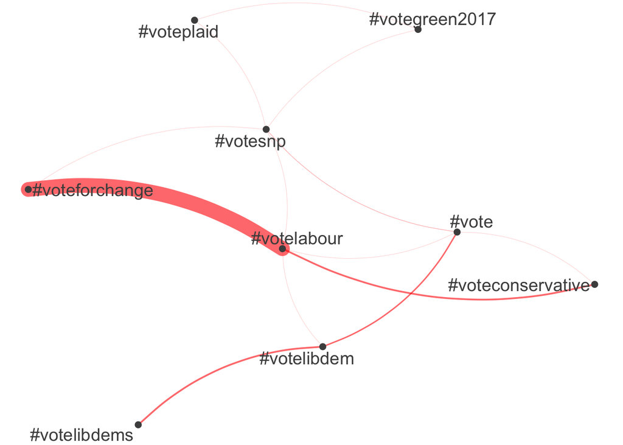

```r
# 2. Create a textplot_network from the most popular hashtags
topgat_fcm <- fcm_select(vote_hashtag_fcm, pattern = top_hashtags)
textplot_network(topgat_fcm, min_freq = 0.1, edge_color = "red", edge_alpha = 0.6, edge_size = 5)
```